# Aim of the project

Gerko Vink

# Load packages

```r
library(mice)
library(readr)
library(countrycode)
library(dplyr)
library(magrittr)
library(purrr)
library(corrplot)
library(psych)
```

# Read in the data

The following data are obtained from [openpsychometrics.org](https://openpsychometrics.org/_rawdata/)

```r
data <- read_delim("Data/data.csv", "\t",
    quote = "\\\"", escape_double = FALSE,
    trim_ws = TRUE)
# some editing
exclude <- c("A1", "A2", "AP", "EU", "FX")
data %<>%
  filter(!country %in% exclude) %>%
  mutate(continent = countrycode(country,
                                 origin="iso2c",
                                 destination = 'continent'))
```

# Add principal component scores

```r
data %<>%
  mutate(principal(cbind(A1, A2, A3, A4, A5, A6, A7, A8, A9, A10)) %>%
           pluck("scores") %>% as.data.frame %>%
           rename(Scale_A = "PC1"),
         principal(cbind(B1, B2, B3, B4, B5, B6, B7, B8, B9, B10)) %>%
           pluck("scores") %>% as.data.frame %>%
           rename(Scale_B = "PC1"),
         principal(cbind(C1, C2, C3, C4, C5, C6, C7, C8, C9, C10)) %>%
           pluck("scores") %>% as.data.frame %>%
           rename(Scale_C = "PC1"),
         principal(cbind(D1, D2, D3, D4, D5, D6, D7, D8, D9, D10)) %>%
           pluck("scores") %>% as.data.frame %>%
           rename(Scale_D = "PC1"),
         principal(cbind(E1, E2, E3, E4, E5, E6, E7, E8, E9, E10)) %>%
           pluck("scores") %>% as.data.frame %>%
           rename(Scale_E = "PC1"),
         principal(cbind(F1, F2, F3, F4, F5, F6, F7, F8, F9, F10)) %>%
           pluck("scores") %>% as.data.frame %>%
           rename(Scale_F = "PC1"),
         principal(cbind(G1, G2, G3, G4, G5, G6, G7, G8, G9, G10)) %>%
           pluck("scores") %>% as.data.frame %>%
           rename(Scale_G = "PC1"),
         principal(cbind(H1, H2, H3, H4, H5, H6, H7, H8, H9, H10)) %>%
           pluck("scores") %>% as.data.frame %>%
           rename(Scale_H = "PC1"),
         principal(cbind(I1, I2, I3, I4, I5, I6, I7, I8, I9, I10)) %>%
           pluck("scores") %>% as.data.frame %>%
           rename(Scale_I = "PC1"),
         principal(cbind(J1, J2, J3, J4, J5, J6, J7, J8, J9, J10)) %>%
           pluck("scores") %>% as.data.frame %>%
           rename(Scale_J = "PC1"),
         principal(cbind(K1, K2, K3, K4, K5, K6, K7, K8, K9, K10)) %>%
           pluck("scores") %>% as.data.frame %>%
           rename(Scale_K = "PC1"),
         principal(cbind(L1, L2, L3, L4, L5, L6, L7, L8, L9, L10)) %>%
           pluck("scores") %>% as.data.frame %>%
           rename(Scale_L = "PC1"),
         principal(cbind(M1, M2, M3, M4, M5, M6, M7, M8, M9, M10)) %>%
           pluck("scores") %>% as.data.frame %>%
           rename(Scale_M = "PC1"),
         principal(cbind(N1, N2, N3, N4, N5, N6, N7, N8, N9, N10)) %>%
           pluck("scores") %>% as.data.frame %>%
           rename(Scale_N = "PC1"),
         principal(cbind(O1, O2, O3, O4, O5, O6, O7, O8, O9, O10)) %>%
           pluck("scores") %>% as.data.frame %>%
           rename(Scale_O = "PC1"),
         principal(cbind(P1, P2, P3, P4, P5, P6, P7, P8, P9, P10)) %>%
           pluck("scores") %>% as.data.frame %>%
           rename(Scale_P = "PC1"))
```

## Correlations of the component scores

```r
cor_scale <- data %>%
  select(contains("Scale_")) %>%
  cor() %>%
  round(2)

cor_scale
```

```
##         Scale_A Scale_B Scale_C Scale_D Scale_E Scale_F Scale_G Scale_H Scale_I
## Scale_A    1.00    0.27   -0.23    0.23    0.46   -0.23    0.52    0.29   -0.40
## Scale_B    0.27    1.00   -0.19    0.43    0.09    0.06    0.12    0.40    0.06
## Scale_C   -0.23   -0.19    1.00   -0.39   -0.20    0.21   -0.46    0.04    0.43
## Scale_D    0.23    0.43   -0.39    1.00    0.32    0.06    0.51    0.09   -0.03
## Scale_E    0.46    0.09   -0.20    0.32    1.00    0.08    0.65    0.01   -0.18
## Scale_F   -0.23    0.06    0.21    0.06    0.08    1.00   -0.09   -0.01    0.34
## Scale_G    0.52    0.12   -0.46    0.51    0.65   -0.09    1.00    0.03   -0.37
## Scale_H    0.29    0.40    0.04    0.09    0.01   -0.01    0.03    1.00   -0.07
## Scale_I   -0.40    0.06    0.43   -0.03   -0.18    0.34   -0.37   -0.07    1.00
## Scale_J    0.04    0.30    0.24    0.02    0.15    0.44   -0.14    0.31    0.27
## Scale_K    0.47    0.04   -0.29    0.29    0.41   -0.14    0.62    0.08   -0.44
## Scale_L    0.03   -0.04    0.73   -0.36   -0.10    0.02   -0.36    0.13    0.29
## Scale_M   -0.23   -0.48    0.13   -0.27   -0.09   -0.21   -0.15   -0.46    0.05
## Scale_N   -0.23    0.33    0.22   -0.07   -0.41    0.14   -0.49    0.25    0.37
## Scale_O   -0.12   -0.18    0.21   -0.26    0.09    0.39   -0.12   -0.02    0.08
## Scale_P   -0.26    0.04    0.54    0.00   -0.03    0.24   -0.24   -0.05    0.51
##         Scale_J Scale_K Scale_L Scale_M Scale_N Scale_O Scale_P
## Scale_A    0.04    0.47    0.03   -0.23   -0.23   -0.12   -0.26
## Scale_B    0.30    0.04   -0.04   -0.48    0.33   -0.18    0.04
## Scale_C    0.24   -0.29    0.73    0.13    0.22    0.21    0.54
## Scale_D    0.02    0.29   -0.36   -0.27   -0.07   -0.26    0.00
## Scale_E    0.15    0.41   -0.10   -0.09   -0.41    0.09   -0.03
## Scale_F    0.44   -0.14    0.02   -0.21    0.14    0.39    0.24
## Scale_G   -0.14    0.62   -0.36   -0.15   -0.49   -0.12   -0.24
## Scale_H    0.31    0.08    0.13   -0.46    0.25   -0.02   -0.05
## Scale_I    0.27   -0.44    0.29    0.05    0.37    0.08    0.51
## Scale_J    1.00   -0.13    0.24   -0.41    0.34    0.31    0.22
## Scale_K   -0.13    1.00   -0.16   -0.12   -0.45   -0.07   -0.18
## Scale_L    0.24   -0.16    1.00    0.11    0.21    0.10    0.51
## Scale_M   -0.41   -0.12    0.11    1.00   -0.11   -0.04    0.20
## Scale_N    0.34   -0.45    0.21   -0.11    1.00   -0.01    0.26
## Scale_O    0.31   -0.07    0.10   -0.04   -0.01    1.00    0.09
## Scale_P    0.22   -0.18    0.51    0.20    0.26    0.09    1.00
```

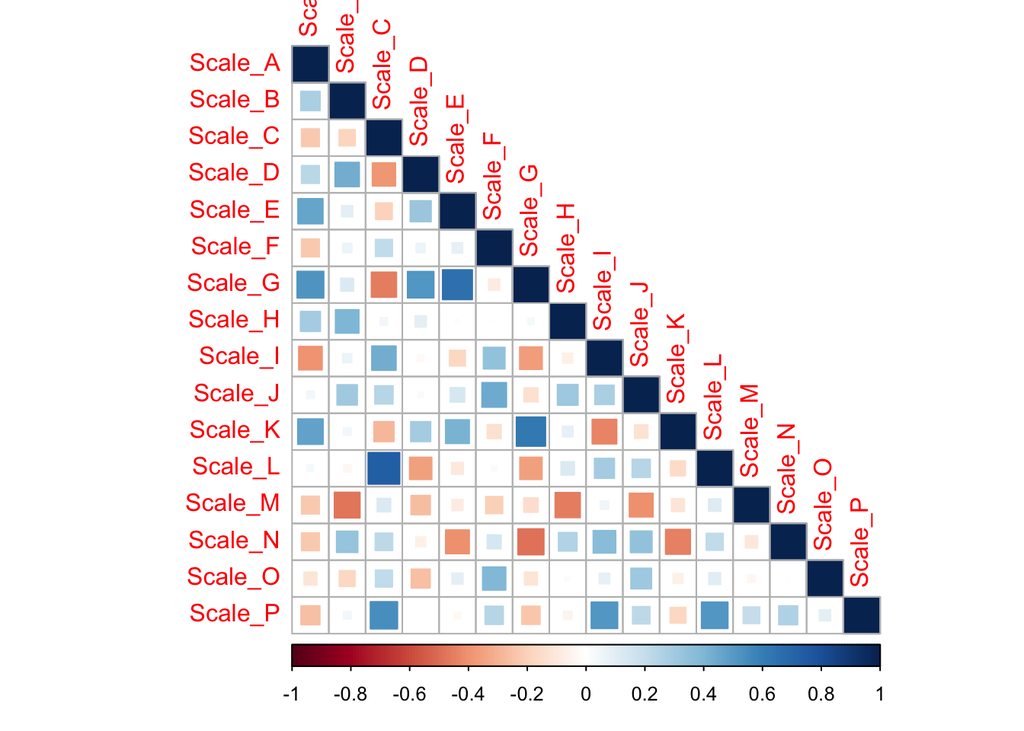

```r
cor_scale %>% corrplot(type = "lower", method = "square")
```

# Add mean scores for the scales

```r
data %<>%
  mutate(Mean_A = data %>% select(starts_with("A", ignore.case = FALSE)) %>% rowMeans,
         Mean_B = data %>% select(starts_with("B", ignore.case = FALSE)) %>% rowMeans,
         Mean_C = data %>% select(starts_with("C", ignore.case = FALSE)) %>% rowMeans,
         Mean_D = data %>% select(starts_with("D", ignore.case = FALSE)) %>% rowMeans,
         Mean_E = data %>% select(starts_with("E", ignore.case = FALSE)) %>% rowMeans,
         Mean_F = data %>% select(starts_with("F", ignore.case = FALSE)) %>% rowMeans,
         Mean_G = data %>% select(starts_with("G", ignore.case = FALSE)) %>% rowMeans,
         Mean_H = data %>% select(starts_with("H", ignore.case = FALSE)) %>% rowMeans,
         Mean_I = data %>% select(starts_with("I", ignore.case = FALSE)) %>% rowMeans,
         Mean_J = data %>% select(starts_with("J", ignore.case = FALSE)) %>% rowMeans,
         Mean_K = data %>% select(starts_with("K", ignore.case = FALSE)) %>% rowMeans,
         Mean_L = data %>% select(starts_with("L", ignore.case = FALSE)) %>% rowMeans,
         Mean_M = data %>% select(starts_with("M", ignore.case = FALSE)) %>% rowMeans,
         Mean_N = data %>% select(starts_with("N", ignore.case = FALSE)) %>% rowMeans,
         Mean_O = data %>% select(starts_with("O", ignore.case = FALSE)) %>% rowMeans,
         Mean_P = data %>% select(starts_with("P", ignore.case = FALSE)) %>% rowMeans)
```

## Correlations of the mean scores

```r
cor_mean <- data %>%
  select(contains("Mean_")) %>%
  cor() %>%
  round(2)

cor_mean
```

```
##        Mean_A Mean_B Mean_C Mean_D Mean_E Mean_F Mean_G Mean_H Mean_I Mean_J
## Mean_A   1.00   0.49   0.40   0.49   0.56   0.50   0.55   0.40   0.44   0.37
## Mean_B   0.49   1.00   0.55   0.56   0.42   0.53   0.56   0.51   0.60   0.50
## Mean_C   0.40   0.55   1.00   0.47   0.40   0.46   0.54   0.45   0.57   0.52
## Mean_D   0.49   0.56   0.47   1.00   0.50   0.55   0.52   0.42   0.53   0.46
## Mean_E   0.56   0.42   0.40   0.50   1.00   0.55   0.55   0.37   0.47   0.50
## Mean_F   0.50   0.53   0.46   0.55   0.55   1.00   0.53   0.41   0.57   0.49
## Mean_G   0.55   0.56   0.54   0.52   0.55   0.53   1.00   0.44   0.56   0.48
## Mean_H   0.40   0.51   0.45   0.42   0.37   0.41   0.44   1.00   0.46   0.38
## Mean_I   0.44   0.60   0.57   0.53   0.47   0.57   0.56   0.46   1.00   0.53
## Mean_J   0.37   0.50   0.52   0.46   0.50   0.49   0.48   0.38   0.53   1.00
## Mean_K   0.45   0.55   0.55   0.48   0.37   0.46   0.55   0.48   0.56   0.48
## Mean_L   0.38   0.53   0.56   0.42   0.35   0.42   0.50   0.42   0.59   0.47
## Mean_M   0.52   0.46   0.45   0.47   0.55   0.54   0.54   0.44   0.48   0.41
## Mean_N   0.37   0.56   0.51   0.44   0.27   0.42   0.49   0.46   0.52   0.50
## Mean_O   0.47   0.62   0.50   0.52   0.46   0.52   0.53   0.48   0.56   0.50
## Mean_P   0.32   0.49   0.49   0.50   0.42   0.49   0.46   0.38   0.58   0.44
##        Mean_K Mean_L Mean_M Mean_N Mean_O Mean_P
## Mean_A   0.45   0.38   0.52   0.37   0.47   0.32
## Mean_B   0.55   0.53   0.46   0.56   0.62   0.49
## Mean_C   0.55   0.56   0.45   0.51   0.50   0.49
## Mean_D   0.48   0.42   0.47   0.44   0.52   0.50
## Mean_E   0.37   0.35   0.55   0.27   0.46   0.42
## Mean_F   0.46   0.42   0.54   0.42   0.52   0.49
## Mean_G   0.55   0.50   0.54   0.49   0.53   0.46
## Mean_H   0.48   0.42   0.44   0.46   0.48   0.38
## Mean_I   0.56   0.59   0.48   0.52   0.56   0.58
## Mean_J   0.48   0.47   0.41   0.50   0.50   0.44
## Mean_K   1.00   0.53   0.47   0.54   0.52   0.46
## Mean_L   0.53   1.00   0.37   0.47   0.50   0.58
## Mean_M   0.47   0.37   1.00   0.38   0.47   0.39
## Mean_N   0.54   0.47   0.38   1.00   0.49   0.42
## Mean_O   0.52   0.50   0.47   0.49   1.00   0.46
## Mean_P   0.46   0.58   0.39   0.42   0.46   1.00
```

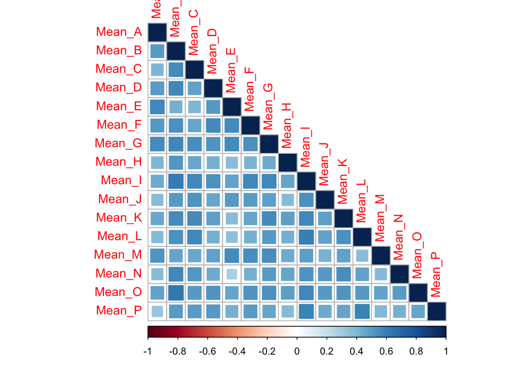

```r
cor_mean %>% corrplot(type = "lower", method = "square")
```

# Aim

The aim is to study the impact of different appraches for dealing with `not applicable's` in incomplete data. The following outline can be defined

1. Induce the Not applicables in the data (e.g with ampute and set the missings to not applicable)
2. Formulate an analysis model using the 16 personality factors
3. Run the analysis model on the data set to obtain the *true* data inference
4. Obtain statistical properties of the *true* data set, such as
- `mean()` for the 16 personality factors
- `variance()` for the 16 personality factors
- `cor()` for the 16 personality factors
- etc.
5. Plot the distributions of the *true* data set
6. Simulate `nsim = 1000` times the following:
- 1. Ampute the data with `ampute()` for a different MAR mechanism.
- 2. Impute the data $m$ times with `mice` for each of the following imputation scenarios:
  - Exclude any row with `not applicable` and impute the missingness in the remaining set.
  - Impute the missingness, but do not allow `not applicable` as an imputation
  - Impute the missingness, allowing `not applicable` as an imputation and for each of the following two methods:
  - impute with `mice.impute.pmm`
  - impute in two-steps where each column is joined with an indicator column (`not applicable` or not) and both columns are imputed. A simple data postprocessing on the imputed data can merge the cells and omit the indicators.
- 3. calculate the same statistical properties as under (3) on each of the $m$ imputed sets
- 4. Run the analysis model on each of the $m$ imputed sets
- 5. Combine the $m$ statistics and parameters from (5b) and (5c) into single inferences`
7. Analyze the simulation results by
- 1. Calculating the average parameters and statistics over the `nsim = 1000` simulations
- 2. Plotting the distributions of the statistics and parameters with e.g. boxplots
- 3. Calculating for all statistics and parameters the bootstrap CI.
- 4. Calculating for all parameters the parametric CI cf. Rubin’s rules.
- 5. Calculating the 95% coverage rates of the parameters and statistics (bootstrap CI and parametric CI)
8. Evaluate the results and determine if and when `mice` would yield valid imputed sets given the studied methods and procedures.

End of document